# Math 643: Problem Set 2

Jade Muyambo

2025-02-11

Question 1

```r
getSymbols(c("BAC", "JPM"), src = "yahoo", from = as.Date("2020-01-01", to = as.Date("2025-01-01")))
```

```
## [1] "BAC" "JPM"
```

```r
head(BAC)
```

```
##            BAC.Open BAC.High BAC.Low BAC.Close BAC.Volume BAC.Adjusted
## 2020-01-02    35.35    35.66   35.29     35.64   37614200     31.47291
## 2020-01-03    34.98    35.15   34.76     34.90   50357900     30.81944
## 2020-01-06    34.41    34.90   34.37     34.85   42185000     30.77528
## 2020-01-07    34.70    34.92   34.53     34.62   34149000     30.57218
## 2020-01-08    34.57    35.19   34.55     34.97   45311600     30.88125
## 2020-01-09    35.30    35.33   34.94     35.03   39861600     30.93423
```

```r
head(JPM)
```

```
##            JPM.Open JPM.High JPM.Low JPM.Close JPM.Volume JPM.Adjusted
## 2020-01-02   139.79   141.10  139.26    141.09   10803700     121.4772
## 2020-01-03   137.50   139.23  137.08    138.34   10386800     119.8742
## 2020-01-06   136.56   138.27  136.50    138.23   10259000     119.7789
## 2020-01-07   137.28   137.86  135.82    135.88   10531300     117.7425
## 2020-01-08   135.70   137.58  135.60    136.94    9695300     118.6610
## 2020-01-09   138.05   138.23  137.04    137.44    9469000     119.0943
```

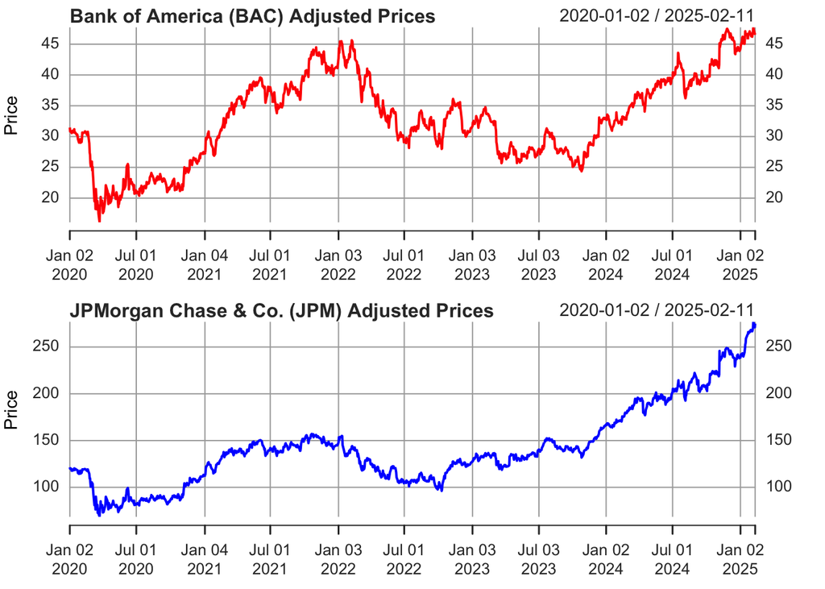

```r
BAC_adjusted <- BAC[, "BAC.Adjusted"]
JPM_adjusted <- JPM[, "JPM.Adjusted"]
par(mfrow = c(2, 1))
plot(BAC_adjusted, main = "Bank of America (BAC) Adjusted Prices", col = "red", ylab = "Price", xlab = "Date")
plot(JPM_adjusted, main = "JPMorgan Chase & Co. (JPM) Adjusted Prices", col = "blue", ylab = "Price", xlab = "Date")
```

Both Bank of America (BAC) and JP Morgan Chase & Co. (JPM) show an overall upward trend in their adjusted prices, indicating that these time series are not stationary because their average values change over time. Adjusted prices reflect actual returns by incorporating dividends and stock splits, which makes them more suitable for long-term analysis. There are periods of noticeable volatility fluctuations, particularly around mid-2020, where BAC experienced a sharp decline, likely due to market-wide events such as the COVID-19 pandemic. BAC’s price movements seems to have more fluctuations compared to JPM, which exhibits a more consistent upward trajectory after 2023. These trends suggest that market conditions, investor sentiment, and economic factors like interest rates significantly influence financial stocks. Since financial stocks tend to be cyclical, they usually follow broader economic trends, with price movements reflecting shifts in market confidence and monetary policy.

Question 2

```r
BAC_log_returns <- diff(log(BAC[,6]))[-1]
JPM_log_returns <- diff(log(JPM[,6]))[-1]
head(BAC_log_returns)
```

```
##            BAC.Adjusted
## 2020-01-03 -0.020981610
## 2020-01-06 -0.001433917
## 2020-01-07 -0.006621333
## 2020-01-08  0.010058841
## 2020-01-09  0.001714271
## 2020-01-10 -0.008312931
```

```r
head(JPM_log_returns)
```

```
##             JPM.Adjusted
## 2020-01-03 -0.0132841500
## 2020-01-06 -0.0007951789
## 2020-01-07 -0.0171468618
## 2020-01-08  0.0077706723
## 2020-01-09  0.0036444462
## 2020-01-10 -0.0100178998
```

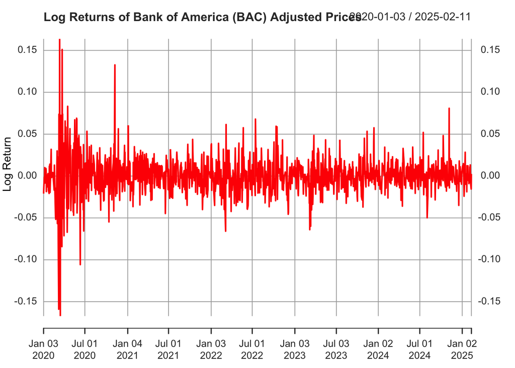

```r
plot(BAC_log_returns, main = "Log Returns of Bank of America (BAC) Adjusted Prices", ylab = "Log Return", col = "red", xlab = "Date")
```

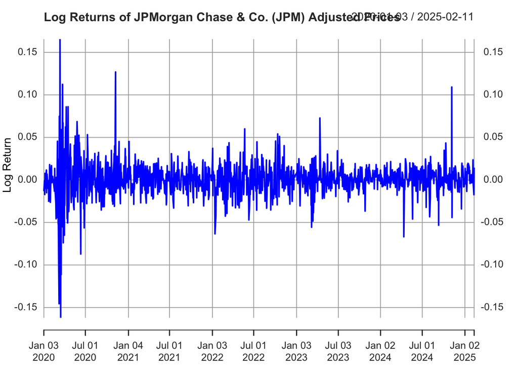

```r
plot(JPM_log_returns, main = "Log Returns of JPMorgan Chase & Co. (JPM) Adjusted Prices", col = "blue", ylab = "Log Return", xlab = "Date")
```

The log return series for Bank of America (BAC) and JP Morgan Chase (JPM) based on the adjusted prices appear to be stationary, meaning their fluctuations occur around a relatively constant mean with no clear upward or downward trend. The returns fluctuate around zero, which is expected since stock prices do not move in a single direction indefinitely. However, there are periods of higher volatility, particularly during market turbulence as seen in the spikes and dips in the log returns.

Additionally, volatility clustering is present, which means that periods of high volatility tend to be followed by continued high volatility, while low-volatility periods remain stable for a while. This is a well-known pattern of the financial time series where external economic events, investor sentiment, or financial crises contribute to sudden bursts of volatility. The log return plots further support the idea that stock prices exhibit a random walk with clustered volatility, making them unpredictable in the short term. This shows that financial models have to account for heavy tails and volatility persistence when analyzing stock returns.

Question 3

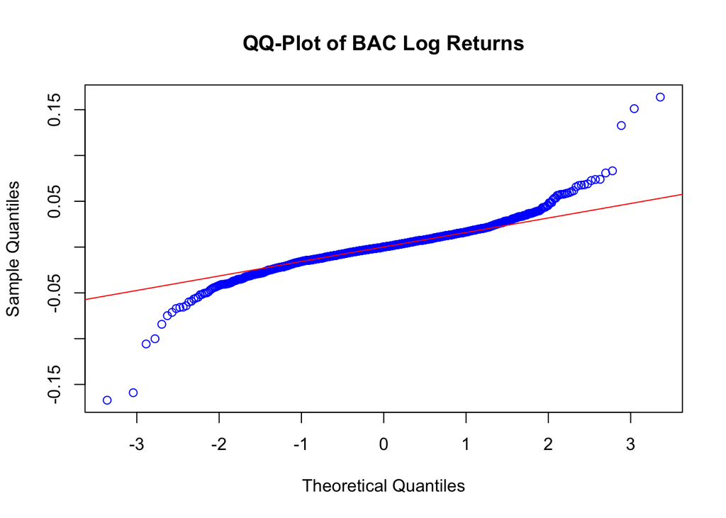

```r
qqnorm(BAC_log_returns, main="QQ-Plot of BAC Log Returns", col="blue")
qqline(BAC_log_returns, col="red")
```

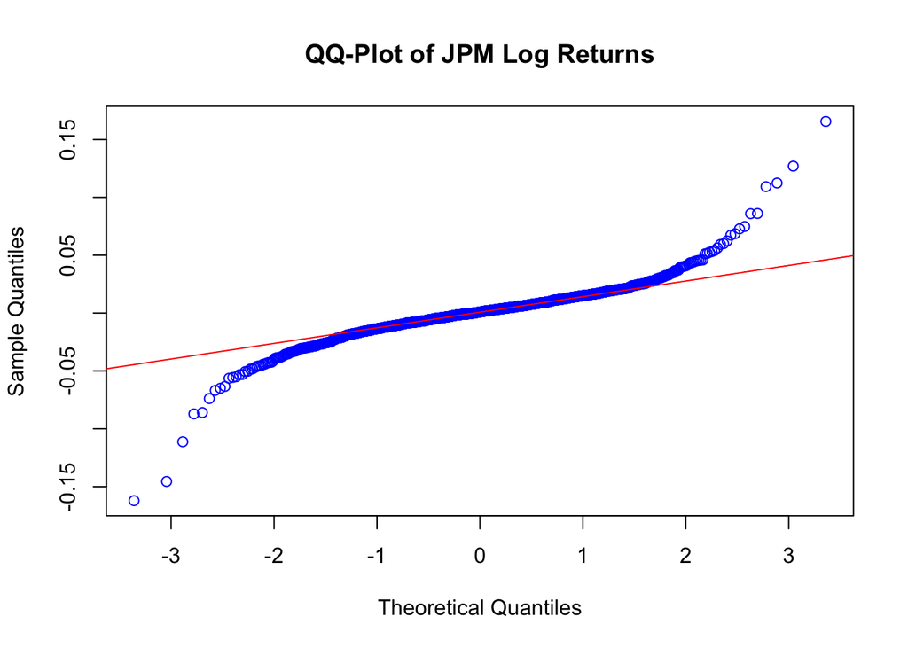

```r
qqnorm(JPM_log_returns, main="QQ-Plot of JPM Log Returns", col="blue")
qqline(JPM_log_returns, col="red")
```

The QQ-plots for the log returns of Bank of America (BAC) and JP Morgan Chase (JPM) show deviations from normality, particularly at the tails. While the middle portion of the distributions closely follows the normal reference line, the data points at the extremes diverge significantly, which indictates heavier tails than expected under a normal distribution. This shows that extreme returns, both positive and negative, happens more frequently than a normal model would predict.

These findings align with the common pattern of financial time series, where stock returns tend to show heavy tails due to market shocks and volatility clustering. Since the normal distribution underestimates the likelihood of extreme returns, alternative models such as the Student-t distribution, which better accounts for heavy tails, may provide a more appropriate fit for modeling these log returns.

Question 4

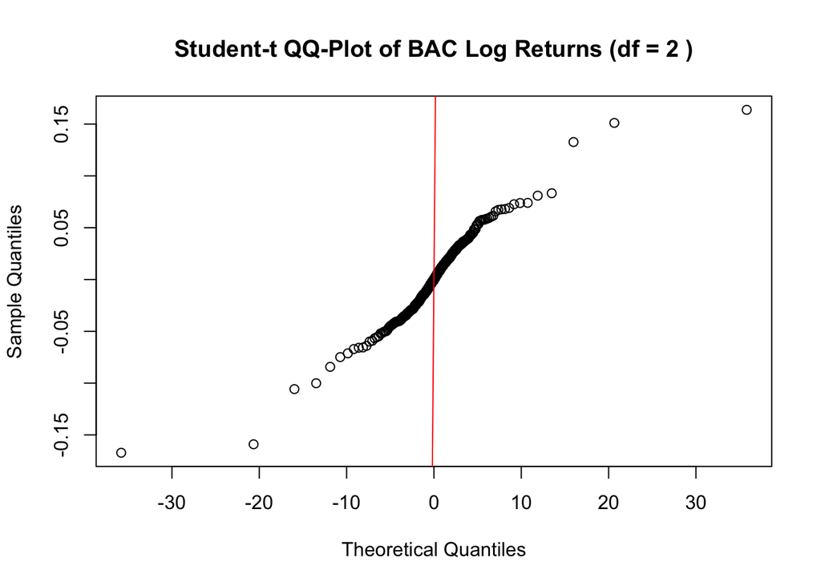

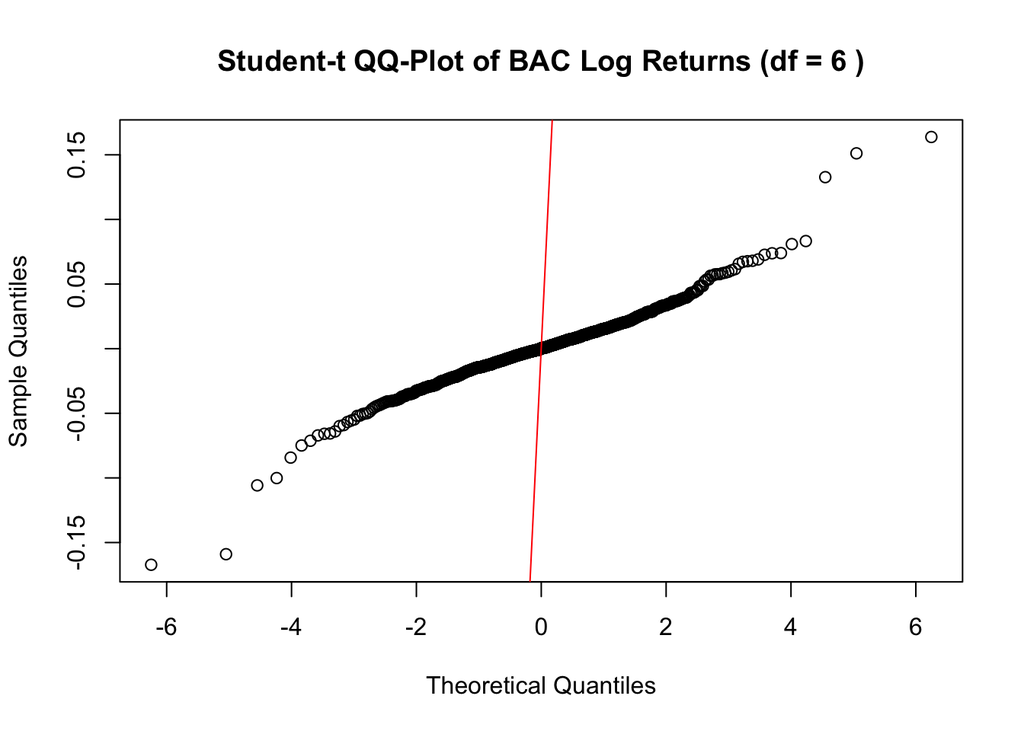

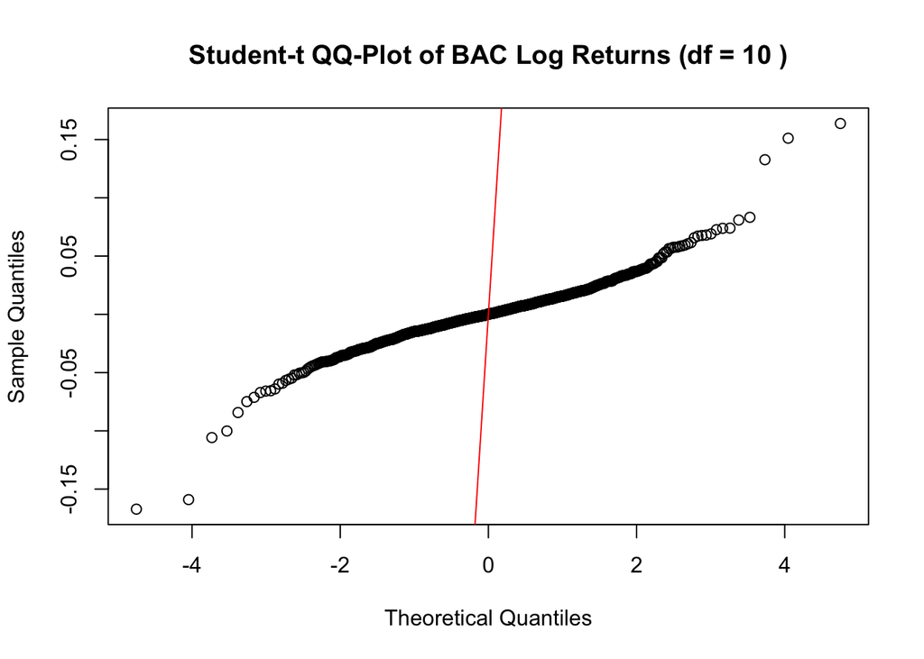

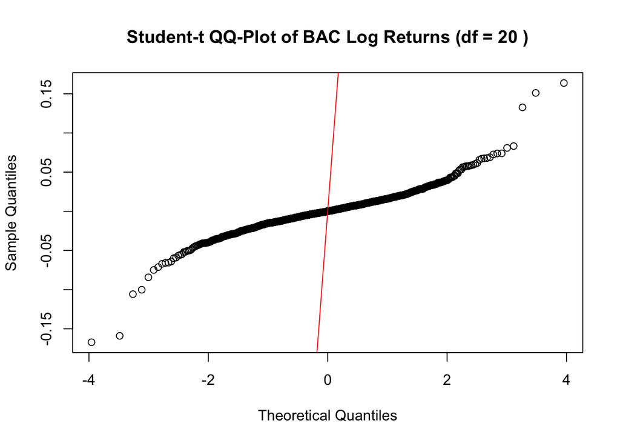

```r
df_values <- c(2, 6, 10, 20)
BAC_numeric <- as.numeric(BAC_log_returns)
for (df in df_values) {
  qqplot(qt(ppoints(length(BAC_numeric)), df = df),
         sort(BAC_numeric, na.last = NA),
         main = paste("Student-t QQ-Plot of BAC Log Returns (df =", df, ")"),
         xlab = "Theoretical Quantiles", ylab = "Sample Quantiles")
  abline(0, 1, col = "red")
}
```

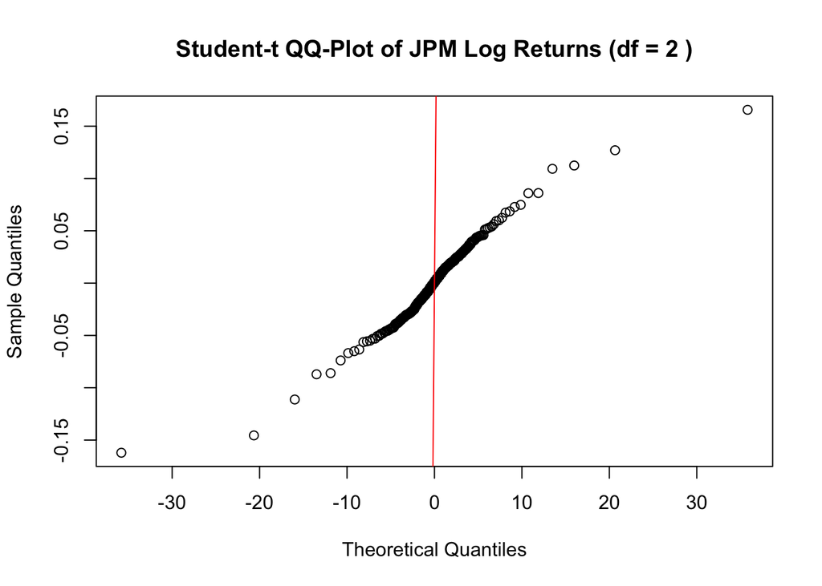

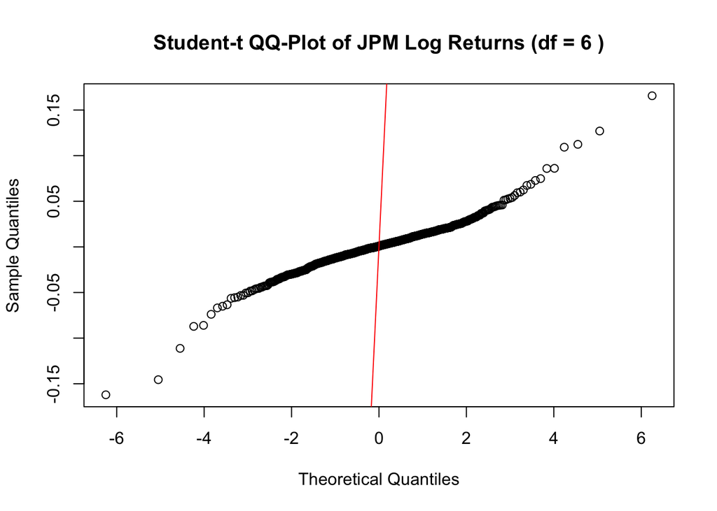

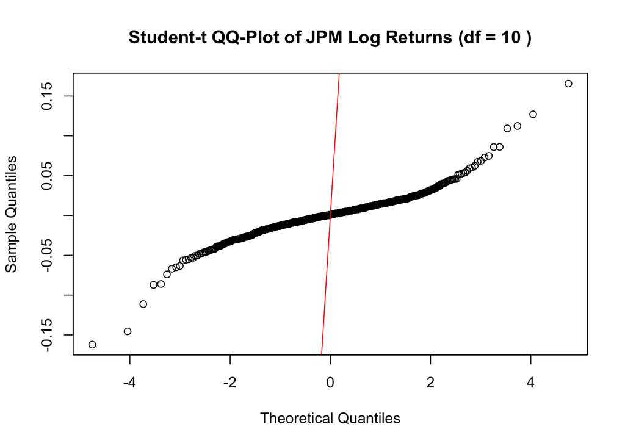

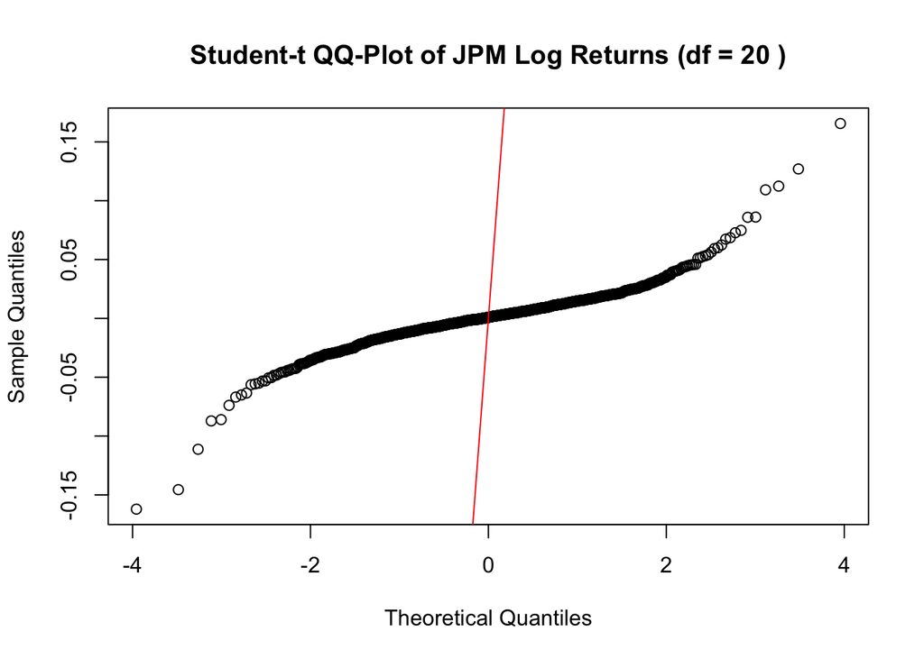

```r
JPM_numeric <- as.numeric(JPM_log_returns)
for (df in df_values) {
  qqplot(qt(ppoints(length(JPM_numeric)), df = df),
         sort(JPM_numeric, na.last = NA),
         main = paste("Student-t QQ-Plot of JPM Log Returns (df =", df, ")"),
         xlab = "Theoretical Quantiles", ylab = "Sample Quantiles")
  abline(0, 1, col = "red")
}
```

Question 5

The log-return series of Bank of America (BAC) and JPMorgan Chase (JPM) share several similarities. Both stocks show heavy tails, which means that extreme price changes, both gains and losses, happen more frequently than expected under a normal distribution. This is evident in the QQ-plots, where deviations at the tails indicate that a normal model is not the best fit. Instead, a Student-t distribution with moderate degrees of freedom (df) provides a better fit. Additionally, both stocks show volatility clustering where periods of high fluctuations tend to follow each other, which is a common characteristic in financial markets.